# Customer characteristics - E-commerce

Andrew Wairegi

28/1/2022

## Defining the Question

### Specifying the question

To help the kenyan entrepreneur to be able to determine who is more likely to click on the ad. From his website.

### Understanding the context

The kenyan entrepreneur has held online courses on his site. But he is unsure if his new courses will do well. So he wants to analyse his existing data, to see what factors affect whether someone will click on his Ad or not. For a new course.

### Data relevance

The data is relevant, because he has sourced it himself. He has gotten it from his own website. Which means that it is original data & is true. This means that it will not give us biased inferences. But will rather give us true data, based on the users on his website. This will allow us to answer his question of whether his users will click on the ad or not.

## Previewing the dataset

```r
library(data.table) # High-performance dataframe package
library(tidyverse) # Data exploration & visualization Package
library(psych) # A Psychometric statistics package
library(corrr) # Correlation's package
library(dplyr) # A Data manipulation package

getMode <- function(v) {     # Get mode function
   uniqv <- unique(v)
   uniqv[which.max(tabulate(match(v, uniqv)))]
}

# Loading the dataset
df = fread("online_shoppers_intention.csv")
```

```r
# Checking the shape
dim(df)
```

```
## [1] 12330    18
```

```r
# Previewing the head
head(df)
```

```
##    Administrative Administrative_Duration Informational Informational_Duration
## 1:              0                       0             0                      0
## 2:              0                       0             0                      0
## 3:              0                      -1             0                     -1
## 4:              0                       0             0                      0
## 5:              0                       0             0                      0
## 6:              0                       0             0                      0
##    ProductRelated ProductRelated_Duration BounceRates ExitRates PageValues
## 1:              1                0.000000  0.20000000 0.2000000          0
## 2:              2               64.000000  0.00000000 0.1000000          0
## 3:              1               -1.000000  0.20000000 0.2000000          0
## 4:              2                2.666667  0.05000000 0.1400000          0
## 5:             10              627.500000  0.02000000 0.0500000          0
## 6:             19              154.216667  0.01578947 0.0245614          0
##    SpecialDay Month OperatingSystems Browser Region TrafficType
## 1:          0   Feb                1       1      1           1
## 2:          0   Feb                2       2      1           2
## 3:          0   Feb                4       1      9           3
## 4:          0   Feb                3       2      2           4
## 5:          0   Feb                3       3      1           4
## 6:          0   Feb                2       2      1           3
##          VisitorType Weekend Revenue
## 1: Returning_Visitor   FALSE   FALSE
## 2: Returning_Visitor   FALSE   FALSE
## 3: Returning_Visitor   FALSE   FALSE
## 4: Returning_Visitor   FALSE   FALSE
## 5: Returning_Visitor    TRUE   FALSE
## 6: Returning_Visitor   FALSE   FALSE
```

```r
# Previewing the tail
tail(df)
```

```
##    Administrative Administrative_Duration Informational Informational_Duration
## 1:              0                       0             1                      0
## 2:              3                     145             0                      0
## 3:              0                       0             0                      0
## 4:              0                       0             0                      0
## 5:              4                      75             0                      0
## 6:              0                       0             0                      0
##    ProductRelated ProductRelated_Duration BounceRates  ExitRates PageValues
## 1:             16                 503.000 0.000000000 0.03764706    0.00000
## 2:             53                1783.792 0.007142857 0.02903061   12.24172
## 3:              5                 465.750 0.000000000 0.02133333    0.00000
## 4:              6                 184.250 0.083333333 0.08666667    0.00000
## 5:             15                 346.000 0.000000000 0.02105263    0.00000
## 6:              3                  21.250 0.000000000 0.06666667    0.00000
##    SpecialDay Month OperatingSystems Browser Region TrafficType
## 1:          0   Nov                2       2      1           1
## 2:          0   Dec                4       6      1           1
## 3:          0   Nov                3       2      1           8
## 4:          0   Nov                3       2      1          13
## 5:          0   Nov                2       2      3          11
## 6:          0   Nov                3       2      1           2
##          VisitorType Weekend Revenue
## 1: Returning_Visitor   FALSE   FALSE
## 2: Returning_Visitor    TRUE   FALSE
## 3: Returning_Visitor    TRUE   FALSE
## 4: Returning_Visitor    TRUE   FALSE
## 5: Returning_Visitor   FALSE   FALSE
## 6:       New_Visitor    TRUE   FALSE
```

```r
# Showing the info
str(df)
```

```
## Classes 'data.table' and 'data.frame':   12330 obs. of  18 variables:
##  $ Administrative         : int  0 0 0 0 0 0 0 1 0 0 ...
##  $ Administrative_Duration: num  0 0 -1 0 0 0 -1 -1 0 0 ...
##  $ Informational          : int  0 0 0 0 0 0 0 0 0 0 ...
##  $ Informational_Duration : num  0 0 -1 0 0 0 -1 -1 0 0 ...
##  $ ProductRelated         : int  1 2 1 2 10 19 1 1 2 3 ...
##  $ ProductRelated_Duration: num  0 64 -1 2.67 627.5 ...
##  $ BounceRates            : num  0.2 0 0.2 0.05 0.02 ...
##  $ ExitRates              : num  0.2 0.1 0.2 0.14 0.05 ...
##  $ PageValues             : num  0 0 0 0 0 0 0 0 0 0 ...
##  $ SpecialDay             : num  0 0 0 0 0 0 0.4 0 0.8 0.4 ...
##  $ Month                  : chr  "Feb" "Feb" "Feb" "Feb" ...
##  $ OperatingSystems       : int  1 2 4 3 3 2 2 1 2 2 ...
##  $ Browser                : int  1 2 1 2 3 2 4 2 2 4 ...
##  $ Region                 : int  1 1 9 2 1 1 3 1 2 1 ...
##  $ TrafficType            : int  1 2 3 4 4 3 3 5 3 2 ...
##  $ VisitorType            : chr  "Returning_Visitor" "Returning_Visitor" "Returning_Visitor" "Returning_Visitor" ...
##  $ Weekend                : logi  FALSE FALSE FALSE FALSE TRUE FALSE ...
##  $ Revenue                : logi  FALSE FALSE FALSE FALSE FALSE FALSE ...
##  - attr(*, ".internal.selfref")=<externalptr>
```

```r
# Checking for null values
colSums(is.na(df))
```

```
##          Administrative Administrative_Duration           Informational
##                      14                      14                      14
##  Informational_Duration          ProductRelated ProductRelated_Duration
##                      14                      14                      14
##             BounceRates               ExitRates              PageValues
##                      14                      14                       0
##              SpecialDay                   Month        OperatingSystems
##                       0                       0                       0
##                 Browser                  Region             TrafficType
##                       0                       0                       0
##             VisitorType                 Weekend                 Revenue
##                       0                       0                       0
```

```r
# Removing null values
df = na.omit(df)

# Checking
colSums(is.na(df))
```

```
##          Administrative Administrative_Duration           Informational
##                       0                       0                       0
##  Informational_Duration          ProductRelated ProductRelated_Duration
##                       0                       0                       0
##             BounceRates               ExitRates              PageValues
##                       0                       0                       0
##              SpecialDay                   Month        OperatingSystems
##                       0                       0                       0
##                 Browser                  Region             TrafficType
##                       0                       0                       0
##             VisitorType                 Weekend                 Revenue
##                       0                       0                       0
```

```r
# Checking for duplicate entries
sum(duplicated(df))
```

```
## [1] 117
```

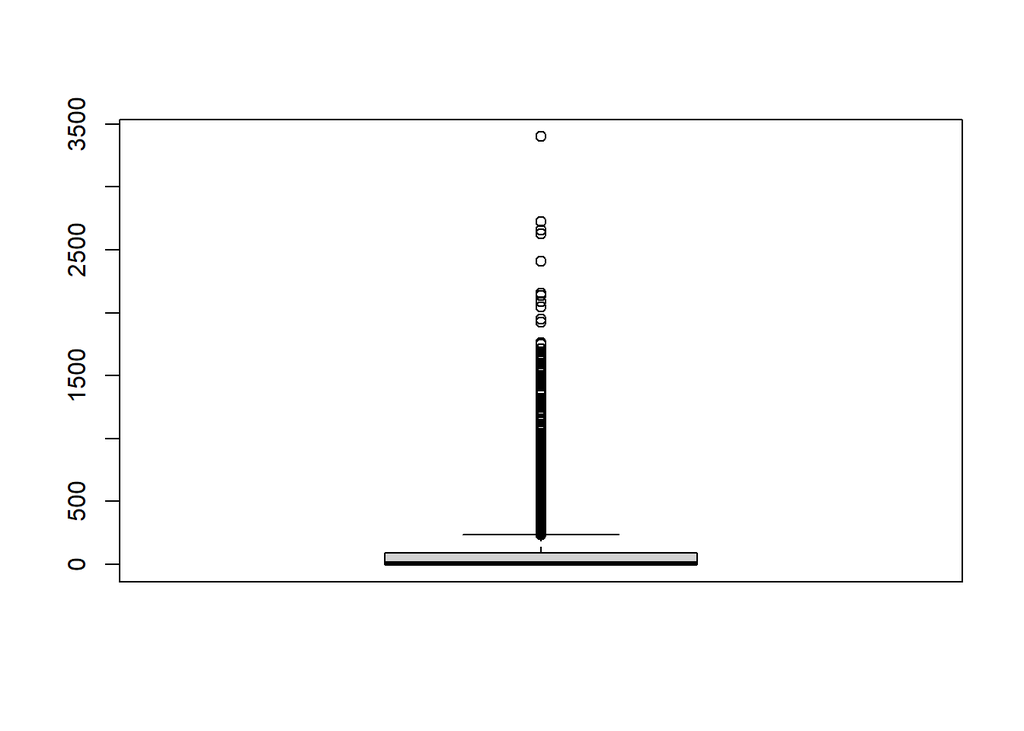

```r
# Checking for outliers

# Administrative duration
boxplot(df$Administrative_Duration)
```

Not abnormal as some users may spend more time on the website. Than others

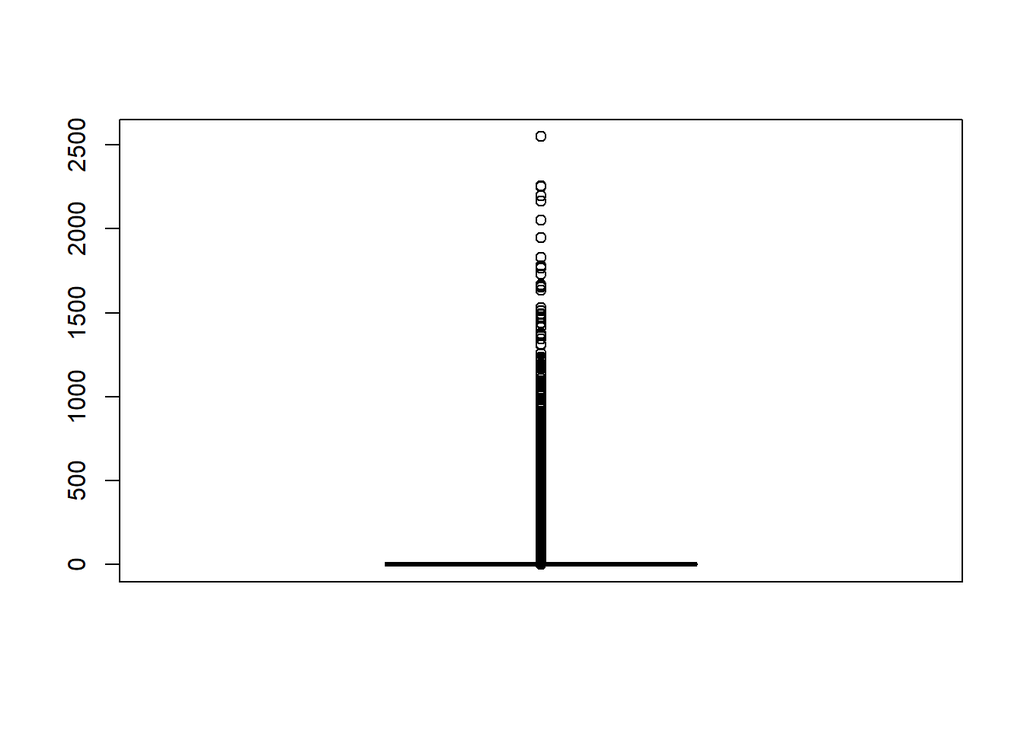

```r
# Informational duration
boxplot(df$Informational_Duration)
```

Not abnormal, as it is normal for some users to spend more time than others. Also since this is informational site viewing. It is normal that the max is much lower than administrative site viewing.

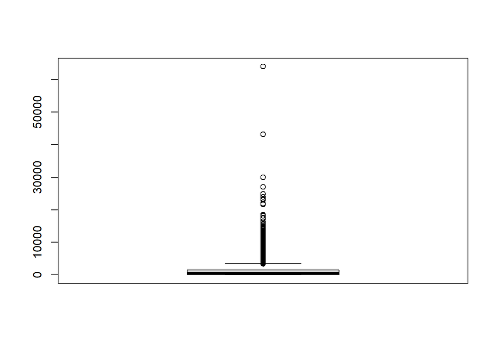

```r
# Informational duration
boxplot(df$ProductRelated_Duration)
```

Product related viewing, had a lot more disparity. But this is because people may have more interest in one product, than another. So it may appear that one product is viewed more than the other.

## Exploratory data analysis

### Univariate analysis

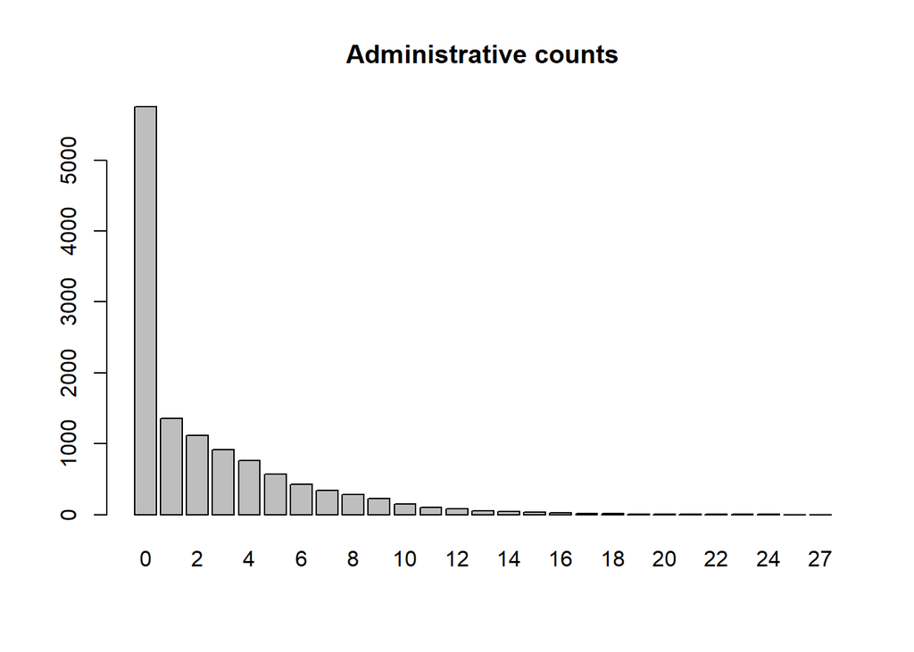

```r
barplot(table(df$Administrative), main = "Administrative counts")
```

Max number of administrative pages visited was 27

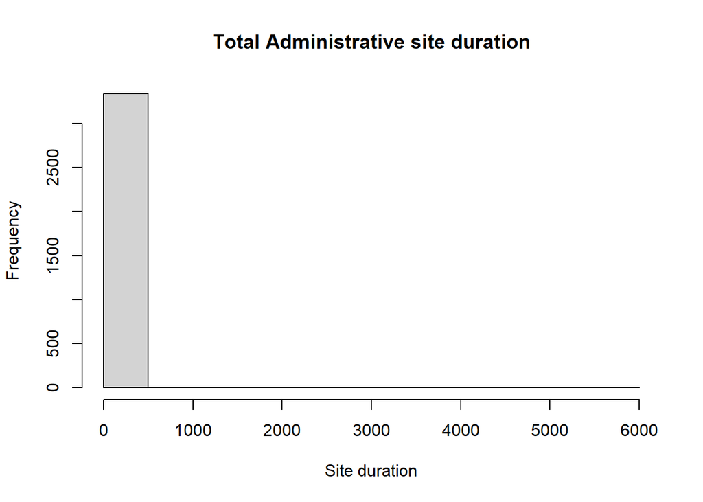

```r
hist(table(df$Administrative_Duration), breaks = 18,  main = "Total Administrative site duration", xlab = "Site duration")
```

Most people spent less than 500 minutes on Administrative sites. On each visit.

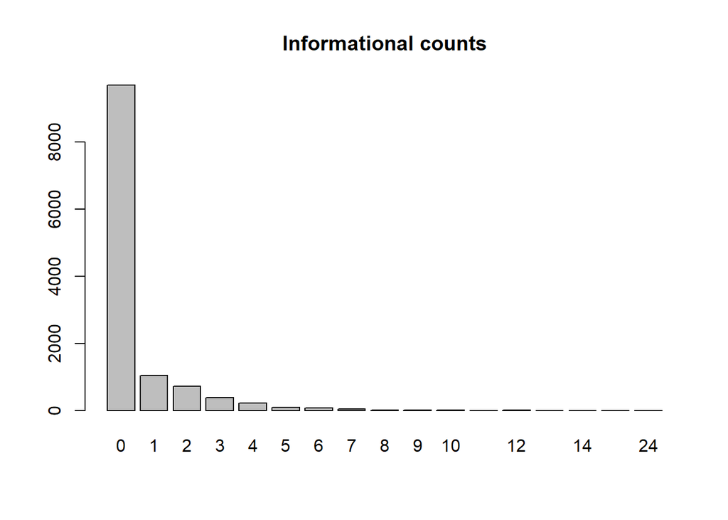

```r
barplot(table(df$Informational), main = "Informational counts")
```

The highest number of sites visited for information. Were 24.

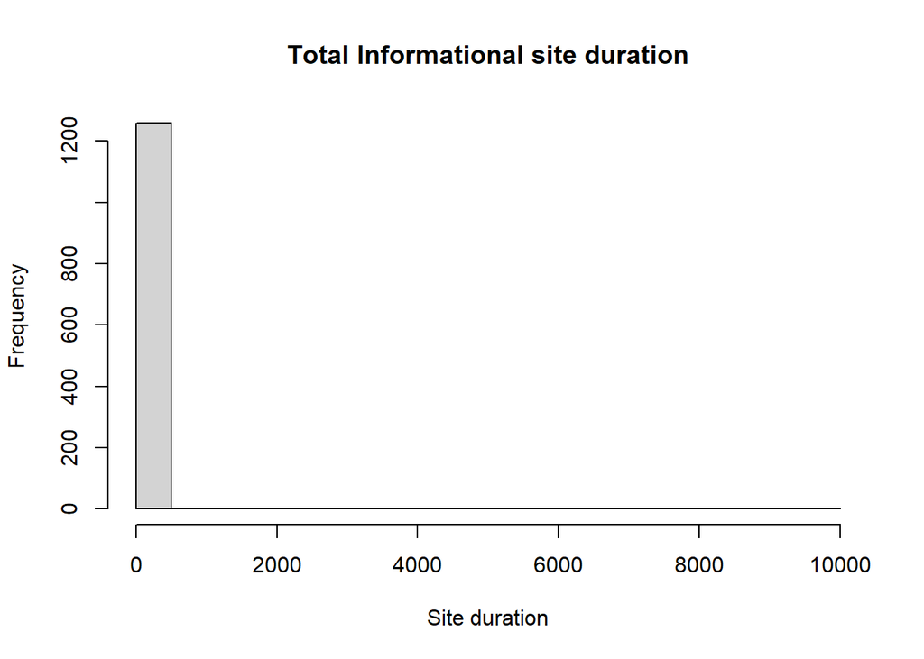

```r
hist(table(df$Informational_Duration), breaks = 18,  main = "Total Informational site duration", xlab = "Site duration")
```

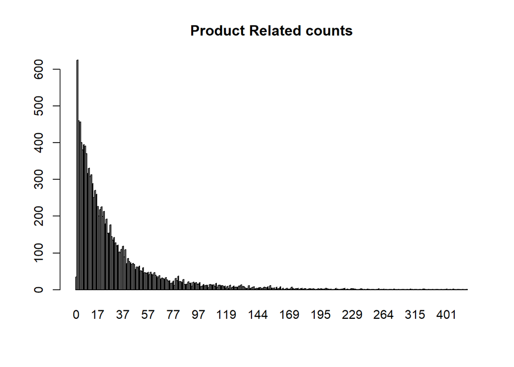

```r
barplot(table(df$ProductRelated), main = "Product Related counts")
```

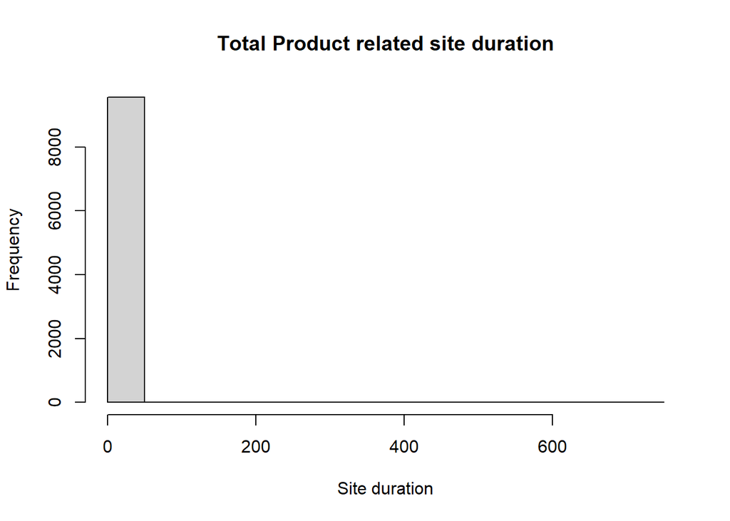

```r
hist(table(df$ProductRelated_Duration), breaks = 20,  main = "Total Product related site duration", xlab = "Site duration")
```

Most people spent less than 50 minutes, looking at products.

```r
# Describe method Keys:
# vars - number of columns being described
# n - number of rows
# mean - mean of column
# sd - standard deviation of column
# min - minimum value in column
# max - maximum value in column
# range - difference between minimum and maximum value
# se - standard error of column


# Administrative duration described
describe(df$Administrative_Duration, interp = TRUE, skew = FALSE, trim = 0.1, quant = NULL, IQR = FALSE)
```

```
##    vars     n  mean     sd min     max   range   se
## X1    1 12316 80.91 176.86  -1 3398.75 3399.75 1.59
```

Mean was 80, and max was 3398 miuntes. Which meant someone must have been browsing the site hard. For information.

```r
# Informational duration described
describe(df$Informational_Duration, interp = TRUE, skew = FALSE, trim = 0.1, quant = NULL, IQR = FALSE)
```

```
##    vars     n  mean     sd min     max   range   se
## X1    1 12316 34.51 140.83  -1 2549.38 2550.38 1.27
```

The mean was 34. Which is normal. As most people won’t be looking for too much informational information on the site. As most of it should be simple, and easy to understand.

```r
# Product related duration described
describe(df$ProductRelated_Duration, interp = TRUE, skew = FALSE, trim = 0.1, quant = NULL, IQR = FALSE)
```

```
##    vars     n    mean      sd min      max    range    se
## X1    1 12316 1196.04 1914.37  -1 63973.52 63974.52 17.25
```

The mean was 1196 minutes. Which is not too high. As someone may look at a lot of products while they are on the site.

```r
# Previewing the head
head(df)
```

```
##    Administrative Administrative_Duration Informational Informational_Duration
## 1:              0                       0             0                      0
## 2:              0                       0             0                      0
## 3:              0                      -1             0                     -1
## 4:              0                       0             0                      0
## 5:              0                       0             0                      0
## 6:              0                       0             0                      0
##    ProductRelated ProductRelated_Duration BounceRates ExitRates PageValues
## 1:              1                0.000000  0.20000000 0.2000000          0
## 2:              2               64.000000  0.00000000 0.1000000          0
## 3:              1               -1.000000  0.20000000 0.2000000          0
## 4:              2                2.666667  0.05000000 0.1400000          0
## 5:             10              627.500000  0.02000000 0.0500000          0
## 6:             19              154.216667  0.01578947 0.0245614          0
##    SpecialDay Month OperatingSystems Browser Region TrafficType
## 1:          0   Feb                1       1      1           1
## 2:          0   Feb                2       2      1           2
## 3:          0   Feb                4       1      9           3
## 4:          0   Feb                3       2      2           4
## 5:          0   Feb                3       3      1           4
## 6:          0   Feb                2       2      1           3
##          VisitorType Weekend Revenue
## 1: Returning_Visitor   FALSE   FALSE
## 2: Returning_Visitor   FALSE   FALSE
## 3: Returning_Visitor   FALSE   FALSE
## 4: Returning_Visitor   FALSE   FALSE
## 5: Returning_Visitor    TRUE   FALSE
## 6: Returning_Visitor   FALSE   FALSE
```

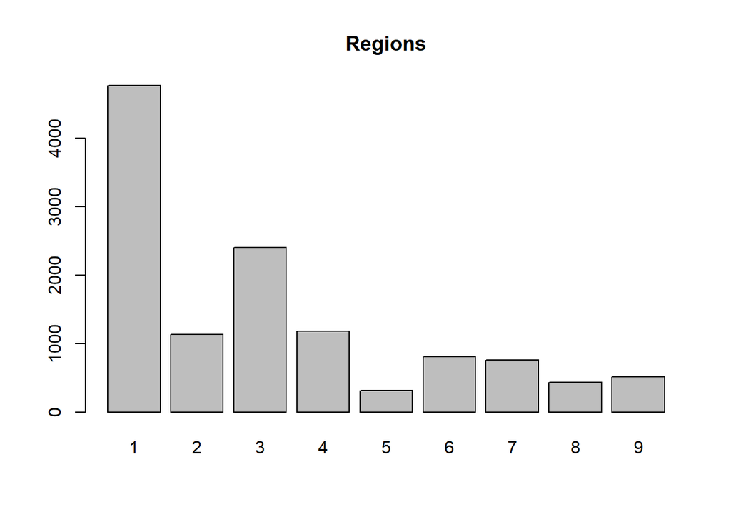

```r
barplot(table(df$Region), main = "Regions")
```

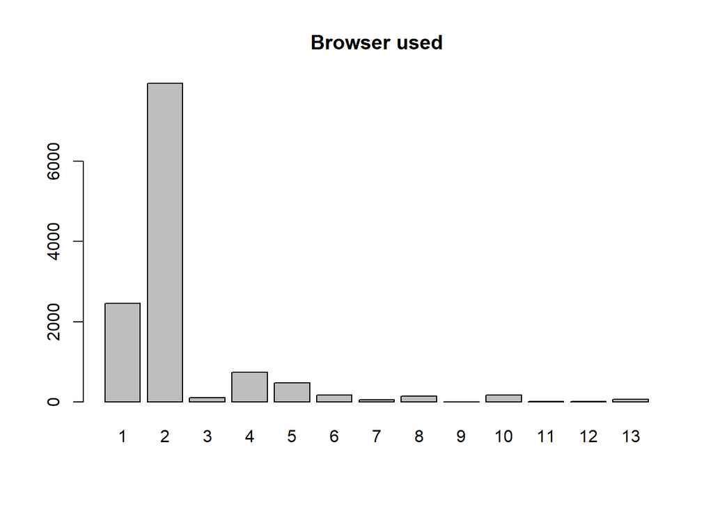

```r
barplot(table(df$Browser), main = "Browser used")
```

There were many browsers used. However the most dominant seemed to be browser 2 & 1.

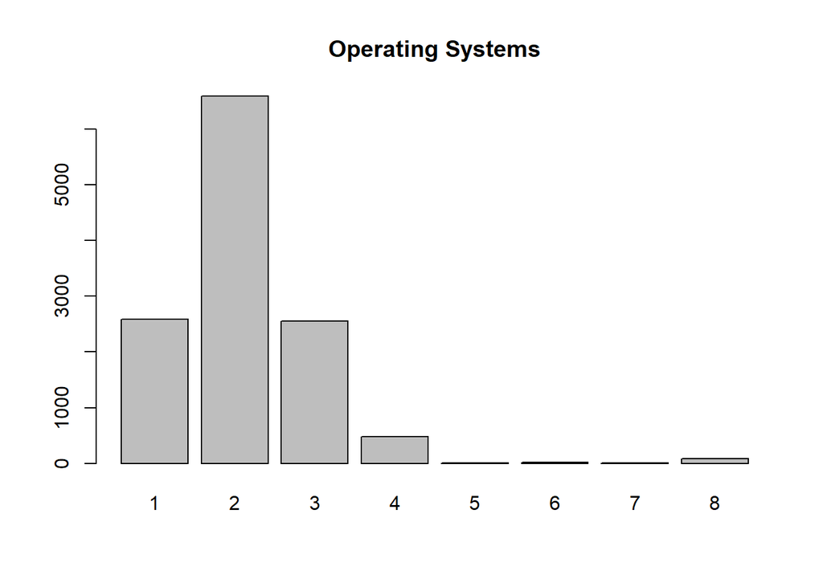

```r
barplot(table(df$OperatingSystems), main = "Operating Systems")
```

### Bivariate analysis

```r
correlation = correlate(select_if(df, is.numeric))
```

```
##
## Correlation method: 'pearson'
## Missing treated using: 'pairwise.complete.obs'
```

```r
correlation
```

```
## # A tibble: 14 x 15
##    term        Administrative Administrative_Du~ Informational Informational_Du~
##    <chr>                <dbl>              <dbl>         <dbl>             <dbl>
##  1 Administra~       NA                  0.601         0.377             0.256
##  2 Administra~        0.601             NA             0.303             0.238
##  3 Informatio~        0.377              0.303        NA                 0.619
##  4 Informatio~        0.256              0.238         0.619            NA
##  5 ProductRel~        0.431              0.289         0.374             0.280
##  6 ProductRel~        0.374              0.355         0.387             0.347
##  7 BounceRates       -0.223             -0.144        -0.116            -0.0741
##  8 ExitRates         -0.316             -0.206        -0.164            -0.105
##  9 PageValues         0.0988             0.0675        0.0485            0.0308
## 10 SpecialDay        -0.0951            -0.0735       -0.0483           -0.0307
## 11 OperatingS~       -0.00646           -0.00742      -0.00943          -0.00960
## 12 Browser           -0.0252            -0.0155       -0.0383           -0.0193
## 13 Region            -0.00568           -0.00568      -0.0294           -0.0272
## 14 TrafficType       -0.0337            -0.0145       -0.0345           -0.0247
## # ... with 10 more variables: ProductRelated <dbl>,
## #   ProductRelated_Duration <dbl>, BounceRates <dbl>, ExitRates <dbl>,
## #   PageValues <dbl>, SpecialDay <dbl>, OperatingSystems <dbl>, Browser <dbl>,
## #   Region <dbl>, TrafficType <dbl>
```

```r
# focus(correlation, `Clicked on Ad`)
```

It seems that some columns are more correlated than others. Which means we may be able to get a good seperation from the clustering machine learning algorithm.

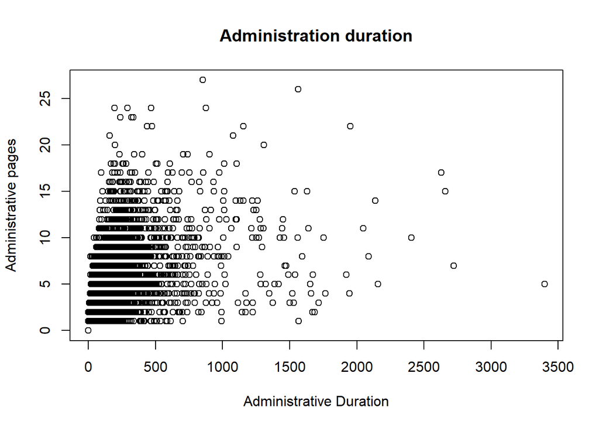

```r
plot(df$Administrative_Duration, df$Administrative , main = "Administration duration", xlab = "Administrative Duration", ylab = "Administrative pages")
```

It seems people were more focused in their searches. And did not spend a bunch of time on pages, to spend time.

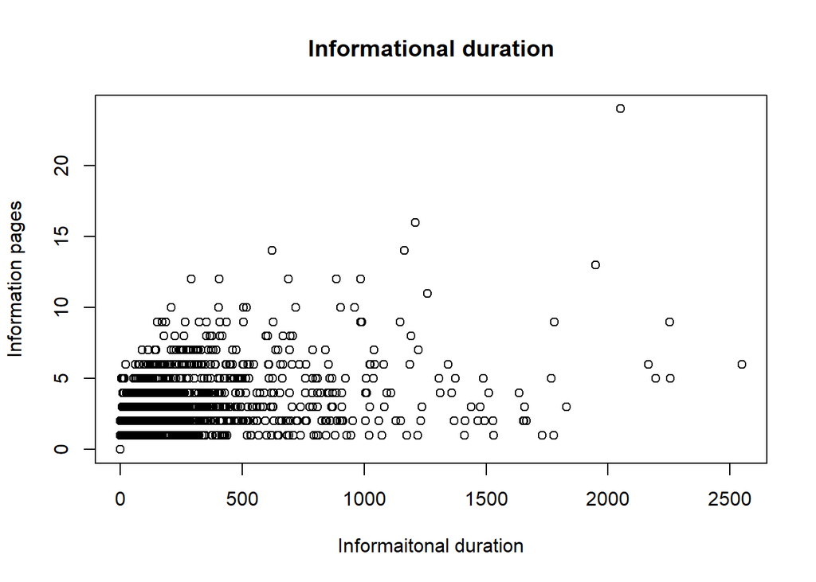

```r
plot(df$Informational_Duration, df$Informational , main = "Informational duration", xlab = "Informaitonal duration", ylab = "Information pages")
```

It seems not many pages were browsed when looking for information. This means that the users knew were to find their information on the page.

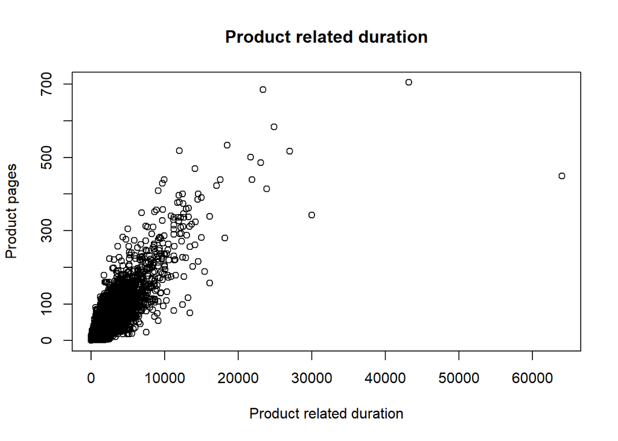

```r
plot(df$ProductRelated_Duration, df$ProductRelated , main = "Product related duration", xlab = "Product related duration", ylab = "Product pages")
```

It seems the more pages. The more time was spent. Which is normal. As it means that the users were able to find more interesting pages on products. While they were shopping.

```r
head(df)
```

```
##    Administrative Administrative_Duration Informational Informational_Duration
## 1:              0                       0             0                      0
## 2:              0                       0             0                      0
## 3:              0                      -1             0                     -1
## 4:              0                       0             0                      0
## 5:              0                       0             0                      0
## 6:              0                       0             0                      0
##    ProductRelated ProductRelated_Duration BounceRates ExitRates PageValues
## 1:              1                0.000000  0.20000000 0.2000000          0
## 2:              2               64.000000  0.00000000 0.1000000          0
## 3:              1               -1.000000  0.20000000 0.2000000          0
## 4:              2                2.666667  0.05000000 0.1400000          0
## 5:             10              627.500000  0.02000000 0.0500000          0
## 6:             19              154.216667  0.01578947 0.0245614          0
##    SpecialDay Month OperatingSystems Browser Region TrafficType
## 1:          0   Feb                1       1      1           1
## 2:          0   Feb                2       2      1           2
## 3:          0   Feb                4       1      9           3
## 4:          0   Feb                3       2      2           4
## 5:          0   Feb                3       3      1           4
## 6:          0   Feb                2       2      1           3
##          VisitorType Weekend Revenue
## 1: Returning_Visitor   FALSE   FALSE
## 2: Returning_Visitor   FALSE   FALSE
## 3: Returning_Visitor   FALSE   FALSE
## 4: Returning_Visitor   FALSE   FALSE
## 5: Returning_Visitor    TRUE   FALSE
## 6: Returning_Visitor   FALSE   FALSE
```

# Implementing the solution

```r
# Since there are three types of customers. I believe we should group the data
# into 3 clusters. As this will allow us to get the most information from the dataset.
# As opposed to clustering it into different groups. Based on what we think the different
# customers are like. In these segments.

kmeans = kmeans(select_if(df, is.numeric), centers = 3, iter.max = 1500)
```

```r
kmeans$centers
```

```
##   Administrative Administrative_Duration Informational Informational_Duration
## 1       1.821985                62.10943     0.3275113               19.98624
## 2       4.325063               154.87748     1.1741772               84.67262
## 3       7.439614               295.36489     2.7487923              266.72309
##   ProductRelated ProductRelated_Duration BounceRates  ExitRates PageValues
## 1       18.63173                577.3255 0.025411677 0.04763612   5.511318
## 2       77.72962               3355.1075 0.007128234 0.02167056   8.013634
## 3      236.10628              10886.1744 0.005939756 0.01968831   4.521370
##   SpecialDay OperatingSystems  Browser   Region TrafficType
## 1 0.06421946         2.121275 2.367772 3.170022    4.149891
## 2 0.05073418         2.136203 2.310380 3.094177    3.710380
## 3 0.03091787         2.149758 2.309179 2.584541    3.618357
```

This makes sense. As most users may visit a variety of pages. So that means the means are not exact to the centres of these centroids.

```r
kmeans$size
```

```
## [1] 10134  1975   207
```

```r
# Viewing the heads of each cluster

# Cluster 1 - Administrative
cluster1 = df[kmeans$cluster == 1]
head(cluster1)
```

```
##    Administrative Administrative_Duration Informational Informational_Duration
## 1:              0                       0             0                      0
## 2:              0                       0             0                      0
## 3:              0                      -1             0                     -1
## 4:              0                       0             0                      0
## 5:              0                       0             0                      0
## 6:              0                       0             0                      0
##    ProductRelated ProductRelated_Duration BounceRates ExitRates PageValues
## 1:              1                0.000000  0.20000000 0.2000000          0
## 2:              2               64.000000  0.00000000 0.1000000          0
## 3:              1               -1.000000  0.20000000 0.2000000          0
## 4:              2                2.666667  0.05000000 0.1400000          0
## 5:             10              627.500000  0.02000000 0.0500000          0
## 6:             19              154.216667  0.01578947 0.0245614          0
##    SpecialDay Month OperatingSystems Browser Region TrafficType
## 1:          0   Feb                1       1      1           1
## 2:          0   Feb                2       2      1           2
## 3:          0   Feb                4       1      9           3
## 4:          0   Feb                3       2      2           4
## 5:          0   Feb                3       3      1           4
## 6:          0   Feb                2       2      1           3
##          VisitorType Weekend Revenue
## 1: Returning_Visitor   FALSE   FALSE
## 2: Returning_Visitor   FALSE   FALSE
## 3: Returning_Visitor   FALSE   FALSE
## 4: Returning_Visitor   FALSE   FALSE
## 5: Returning_Visitor    TRUE   FALSE
## 6: Returning_Visitor   FALSE   FALSE
```

```r
# Cluster 2 - Informational
cluster2 = df[kmeans$cluster == 2]
head(cluster2)
```

```
##    Administrative Administrative_Duration Informational Informational_Duration
## 1:              0                 0.00000             0                      0
## 2:              0                 0.00000             0                      0
## 3:              1                 9.00000             0                      0
## 4:              4                44.00000             0                      0
## 5:             10              1005.66667             0                      0
## 6:              3                18.33333             0                      0
##    ProductRelated ProductRelated_Duration BounceRates   ExitRates PageValues
## 1:             20                2981.167 0.000000000 0.010000000    0.00000
## 2:             52                2086.243 0.015384615 0.020352564    0.00000
## 3:             46                4084.394 0.000000000 0.001794872    0.00000
## 4:             90                6951.972 0.002150538 0.015013034    0.00000
## 5:             36                2111.342 0.004347826 0.014492754   11.43941
## 6:             38                2635.178 0.000000000 0.008947368    0.00000
##    SpecialDay Month OperatingSystems Browser Region TrafficType
## 1:        0.0   Feb                2       4      4           4
## 2:        0.0   Feb                2       2      7           1
## 3:        0.0   Feb                2       2      8           4
## 4:        0.0   Feb                4       1      1           3
## 5:        0.0   Feb                2       6      1           2
## 6:        0.4   Feb                2       4      1           2
##          VisitorType Weekend Revenue
## 1: Returning_Visitor   FALSE   FALSE
## 2: Returning_Visitor   FALSE   FALSE
## 3: Returning_Visitor   FALSE   FALSE
## 4: Returning_Visitor   FALSE   FALSE
## 5: Returning_Visitor   FALSE    TRUE
## 6: Returning_Visitor   FALSE   FALSE
```

```r
# Cluster 3 - Product related
cluster3 = df[kmeans$cluster == 3]
head(cluster3)
```

```
##    Administrative Administrative_Duration Informational Informational_Duration
## 1:             14                416.3929             6               449.3333
## 2:             10                316.1405             7               321.6667
## 3:             11                247.3333             2               369.0000
## 4:              1                 24.0000             3               125.5000
## 5:              3                184.6889             0                 0.0000
## 6:              5                710.3333             0                 0.0000
##    ProductRelated ProductRelated_Duration BounceRates   ExitRates PageValues
## 1:            258               11301.204 0.000000000 0.007425380  33.611792
## 2:            287               12983.788 0.000668896 0.006998399   1.088158
## 3:             90                7221.000 0.001030928 0.003917526  13.464063
## 4:             65                8646.000 0.000000000 0.011764706   0.000000
## 5:            129                7669.251 0.000000000 0.009135204   0.000000
## 6:             23                7533.273 0.000000000 0.007407407   0.000000
##    SpecialDay Month OperatingSystems Browser Region TrafficType
## 1:          0   Mar                2       4      9           2
## 2:          0   Mar                2       4      3           8
## 3:          0   Mar                2       2      3           8
## 4:          0   Mar                2       2      1          13
## 5:          0   Mar                2       2      8          13
## 6:          0   Mar                2       2      1           2
##          VisitorType Weekend Revenue
## 1: Returning_Visitor   FALSE    TRUE
## 2:       New_Visitor   FALSE   FALSE
## 3: Returning_Visitor   FALSE    TRUE
## 4: Returning_Visitor    TRUE   FALSE
## 5: Returning_Visitor   FALSE   FALSE
## 6: Returning_Visitor   FALSE   FALSE
```

## Exploratory data analysis

### Cluster 1

```r
describe(cluster1$BounceRates, interp = TRUE, skew = FALSE, trim = 0.1, quant = NULL, IQR = FALSE)
```

```
##    vars     n mean   sd min max range se
## X1    1 10134 0.03 0.05   0 0.2   0.2  0
```

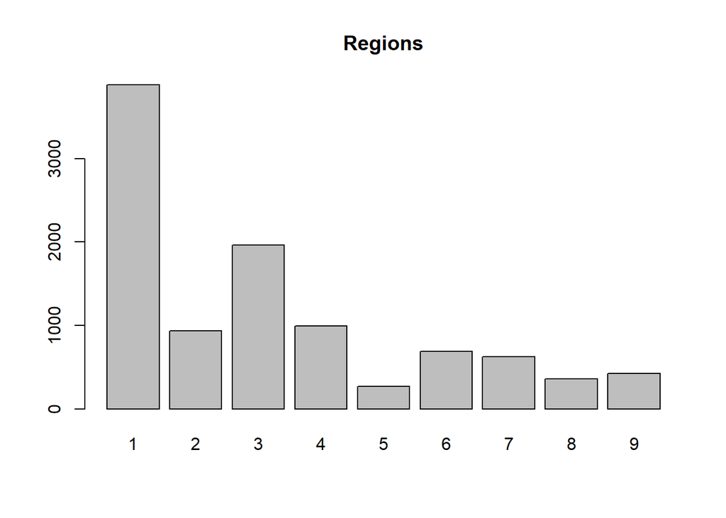

```r
barplot(table(cluster1$Region), main = "Regions")
```

The regions are distributed the same as before. So that means those looking for administrative data were from all regions.

### Cluster 2

```r
describe(cluster2$BounceRates, interp = TRUE, skew = FALSE, trim = 0.1, quant = NULL, IQR = FALSE)
```

```
##    vars    n mean   sd min max range se
## X1    1 1975 0.01 0.01   0 0.1   0.1  0
```

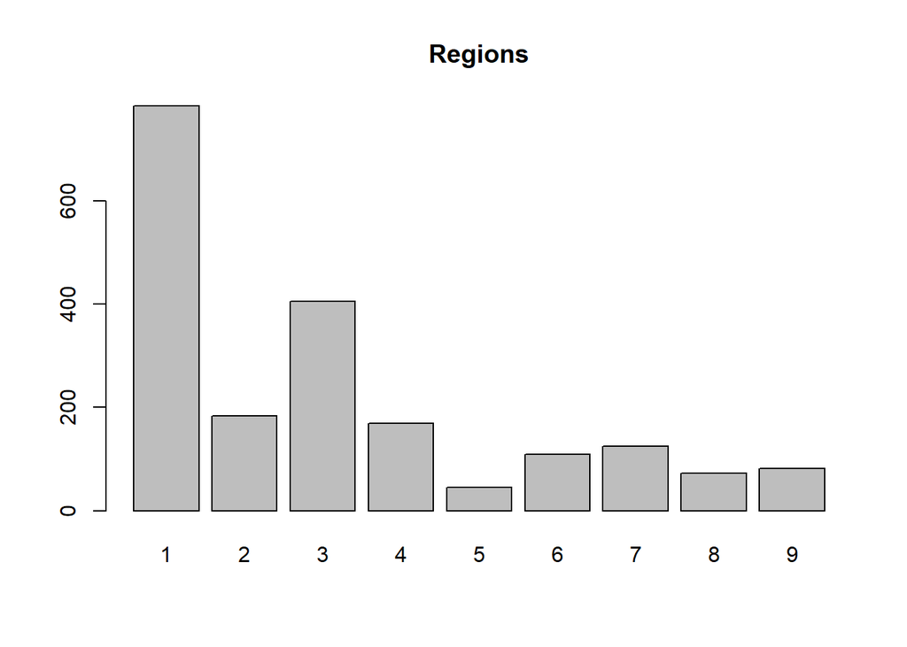

```r
barplot(table(cluster2$Region), main = "Regions")
```

Again information users are from all regions. So that means they may not be seperated from the administrative users. Which means all users, need information from the website.

### Cluster 3

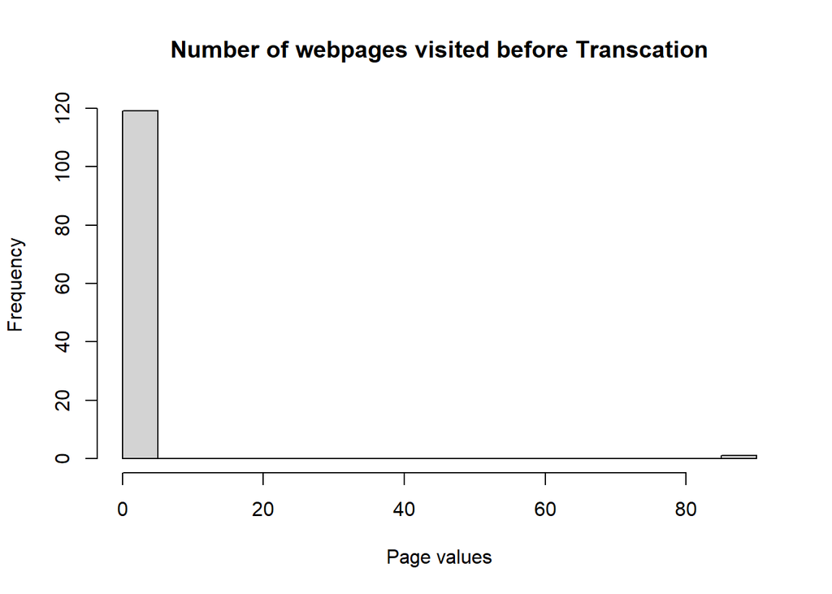

```r
hist(table(cluster3$PageValues), breaks = 15,  main = "Number of webpages visited before Transcation", xlab = "Page values")
```

```r
quantile(cluster3$PageValues)
```

```
##        0%       25%       50%       75%      100%
##  0.000000  0.000000  1.033757  5.437383 59.424589
```

```r
getMode(cluster3$Month)
```

```
## [1] "Nov"
```

Most people did this shopping in around November. Which corresponds to our belief that this is the product viewing cluster.

```r
describe(cluster3$BounceRates, interp = TRUE, skew = FALSE, trim = 0.1, quant = NULL, IQR = FALSE)
```

```
##    vars   n mean   sd min  max range se
## X1    1 207 0.01 0.01   0 0.05  0.05  0
```

Bounce rates were low, as people knew what sites to visit. This can be seen in the mean & max

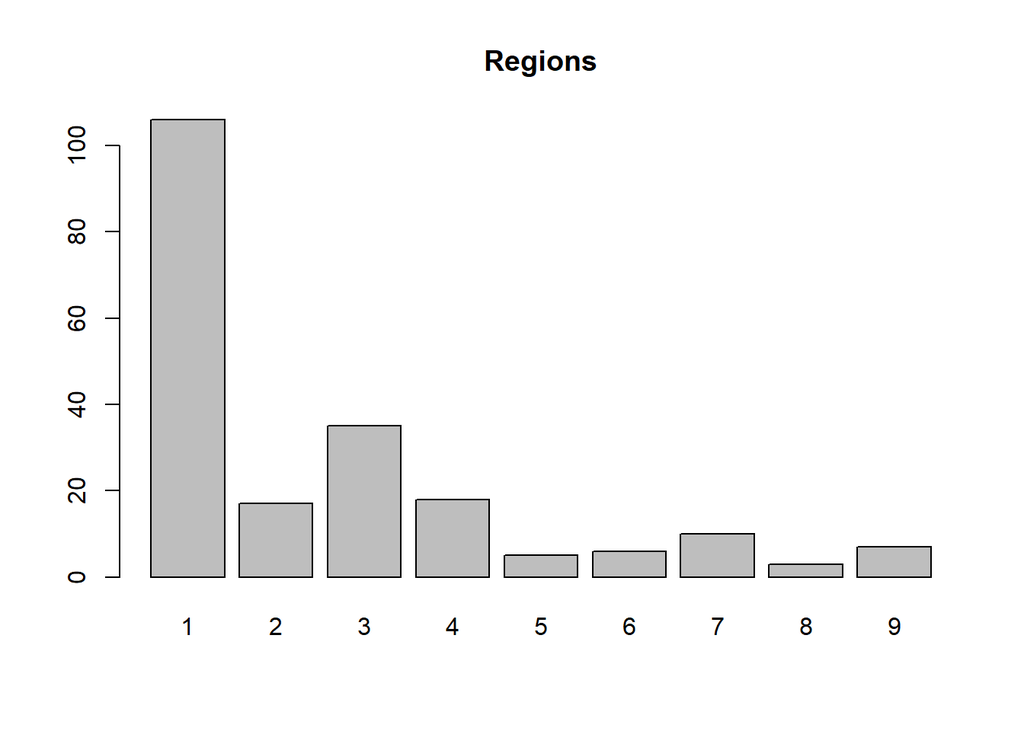

```r
barplot(table(cluster3$Region), main = "Regions")
```

# Challenging the Solution

# Follow up Questions

## a) Did we have the right data?

yes, we had the right data. As it allowed us to find the clusters from within the e-commerce site. This allowed us to get various insights from the data.

## b) Do we need other data to answer our question?

No, because we were able to get the appropriate insights from our data. However we can add more data to our data. If we want to get more insights from it.

## c) Did we have the right question?

Yes, because we want to identify different trends within the different sectors within the company.